# Primer Design FASTA input

```r
require(tidyverse)
require(knitr)
```

# Rationale

In this notebook, we develop the raw fasta file from which Nate Campbell will apply his primer design algorithm for the Albacore GTseq panel

Data comes from several sources (stacks runs) so we must be cautious in retrieving this information.

# Format

Quote from email exchange:

> To get started with primer design I will need a fasta file in this format.

> Locus123 AACGACCACAAGAATTTGTGTGCCAG[G/T]AAGATAGGACCCAGCCGATAATAGGACACGT

> Any non-target variation should be masked with either an “N” or with a base ambiguity code “K,L,M,R,S…”. Ideally we want about 100 bases of flanking sequence on either side of the target SNP but I realize this isn’t always possible with RAD data. Since the analysis already uses a reference genome, I can use the vcf file to gather flanking sequence data and format the input file for primer design. Alternatively, since the bluefin reference genome was used for the analysis, I can use consensus target RAD tag sequences to map back to an albacore reference genome and use the map positions to produce the input file for primer design. Since target loci can come from 3 different analyses, I suggest sending consensus sequences from Stacks tsv files. I can map these sequences to an albacore reference genome and gather flanking sequence from there for primer design.

So it looks like Nate needs three files:  
(1) The reference genome  
(2) A Fasta formatted file with the full stacks locus containing the SNP/SNPs we are targeting and variants flagged with [T/C]  
(3) A vcf file with more SNP info

We could get away with just 1 and 3, but given that our reference genome is from a different species, going from 2 will be an improvement because stacks makes consensus sequences for the stacks loci and these will contain any non-reference variants, even if it is non-polymorphic within the albacore samples and therefore easy to make a bioinformatic mistake and forget to include in the vcf.

# Vaux SNPs

## Stacks Catalog

Which is the correct stacks catalog?

To overcome filtering steps that require a priori knowledge of population structure, Vaux used 9 different stacks runs to conduct the analyses in the ms. As a consequence we must be extra cautious that we build the input file for the panel design from the correct data.

Here, used the appendix from the ms (table A11) to verify which of the 9 different stacks runs is the catalog used to generate the SNP dataset used for FST outlier analysis in Vaux ms

```bash
# checked by pulling one of the 84 N-S significant SNPS from table A11, then checking that the stacks catalog number, snp position and chromosome/contig ID

# e.g. SNP 19, the stacks catalog is 23907, the stacks locus start site 12194 + 127 -1 = 12320, and the contig is BADN01001835.1 (for - strand)

zcat ./*/catalog.fa.gz | grep ">23907 pos=BADN01001835.1"

# only one of the many stacks catalogs matched for the loci we checked (SNPs 19, 30, and 80), each search across all stacks catalogs only found a single match between stacks catalog locus number and contig, and for each of these matches the SNP position was perfect
```

The correct stacks catalog is ori-pac-1 ( full directory location: /dfs/Omalley_Lab/vauxf/STACKS/stacks_out/albacore/ori-pac-1/catalog.fa.gz )

## Vaux SNPs Check

Now that we know we have the right SNP catalog matching the table from the supplemental files. Let’s quickly check that these are definitely the correct SNPs.

Here we pull these SNPs and check to make sure they strognly differentiate N from S Pac samples.

### Which Filtering Set

Within each of the 9 stacks catalogs, there are many filtering steps. According to table A4, the final set used -p 2 and -r 0.95, however, three different final filtered vcf files match these parameters.

Below are the actual calls to populations used in each of these three directories:

**ori-pac-1-p2-r95-a**  
populations -t 25 -P /nfs1/FW_HMSC/OMalley_Lab/vauxf/STACKS/stacks_out/albacore/ori-pac-1 -M /nfs1/FW_HMSC/OMalley_Lab/vauxf/STACKS/population_maps/albacore/12-2P-bam1.txt -r 0.95 -p 2 –min_maf 0.05 –write_single_snp –structure –fstats –fst_correction bonferroni_win –genepop –plink –vcf –hzar –fasta_samples –fasta_loci

Summary: correct stacks catalog, maf filtering, p 2 and r 0.95, no other filtering

**ori-pac-1-p2-r95-a2**  
populations -t 30 -P /nfs1/FW_HMSC/OMalley_Lab/vauxf/STACKS/stacks_out/albacore/ori-pac-1 -M /nfs1/FW_HMSC/OMalley_Lab/vauxf/STACKS/population_maps/albacore/12-2P-bam1.txt -B /nfs1/FW_HMSC/OMalley_Lab/vauxf/STACKS/blacklists/albacore/ori-pac-1-p2-r90-PSV-LD-C1.blacklist -r 0.95 -p 2 –min_maf 0.05 –write_single_snp –structure –fstats –fst_correction bonferroni_win –genepop –plink –vcf –hzar –fasta_samples –fasta_loci

Summary: correct stacks catalog, maf filtering, p 2 and r 0.95, PSV and LD filtering using the C1 blacklist (971 markers)

**ori-pac-1-p2-r95-a3**  
populations -t 30 -P /nfs1/FW_HMSC/OMalley_Lab/vauxf/STACKS/stacks_out/albacore/ori-pac-1 -M /nfs1/FW_HMSC/OMalley_Lab/vauxf/STACKS/population_maps/albacore/12-2P-bam1.txt -B /nfs1/FW_HMSC/OMalley_Lab/vauxf/STACKS/blacklists/albacore/ori-pac-1-p2-r90-PSV-LD-C2.blacklist -r 0.95 -p 2 –min_maf 0.05 –write_single_snp –structure –fstats –fst_correction bonferroni_win –genepop –plink –vcf –hzar –fasta_samples –fasta_loci

Summary: correct stacks catalog, maf filtering, p 2 and r 0.95, PSV and LD filtering using the C2 blacklist (1490 markers)

**Correct Final Filtered Dataset**

Using the information in table 2 and table a4, ori-pac-1-p2-r95-a3 is a perfect match to the manuscript. The correct vcf file is at /dfs/Omalley_Lab/vauxf/STACKS/stacks_out/albacore/ori-pac-1/ori-pac-1-p2-r95-a3/ori-pac-1-p2-r95-a3.vcf and locally at ./input_data/vaux_data/ori-pac-1-p2-r95-a3.vcf

## N-S Fst Outliers

Here we write a file of the 84 SNPs in the correct format for Campbell’s script and write associated metadata for these SNPs to keep for the long run.

First we get info about the SNPs from table A11.

```r
# copied table a11 into text editor and formated into tsv
n_s_84_info <- read_tsv("panel_info/n_s_84_info.txt")

# next lets collect the correct SNP position, note this differs between + and - strand

# lets also create a standardized (across all stacks runs) name for SNPs based on the reference genome and mapping position

n_s_84_info <- n_s_84_info %>%
  mutate(stack_pos_contig = case_when(
    strand == "-" ~ snp_pos_contig + stacks_locus_pos -1,
    strand == "+" ~ snp_pos_contig - stacks_locus_pos +1)) %>%
  mutate(snpID = paste(contig, snp_pos_contig, sep = "_"))

# lets create a standardized (across all stacks runs) name for SNPs based on the reference genome and mapping position

write_tsv(n_s_84_info, file = "panel_info/n_s_84_info.txt")
```

## Nearby variants

One issue here is that the populations run used –write-single-SNP. We want to flag all variants near the target locus to make sure primer and probe design will not fail due to unaccounted for variation. We will need to run populations again without this option and check the resulting vcf file for nearby variants.  
Another concern is skipping lower MAF variants nearby that will lead to allele dropout in the GTseq panel runs if not accounted for now. Given that the majority of variation (as estimated in the unbiased/filtered SFS) occurs at relatively rare SNPs in this species (i.e. less than maf: 0.05), it seems important to not lose this information. Therefore dropping the MAF filtering and including a MAC filter of 3 (i.e. SNP must be seen in at least 2 individuals to be retained), might be better way to check for nearby SNPs to our target SNPs, even if MAF 5% may be justified for final analyses.

```bash
# from the dir /dfs/Omalley_Lab/dayan/albacore/feature_selection/stacks/vaux_run_multisnp


SGE_Batch -q chinook -P 30 -f 30G -m 36G -c '/local/cluster/stacks/stacks-2.41/bin/populations -t 30 -P /dfs/Omalley_Lab/vauxf/STACKS/stacks_out/albacore/ori-pac-1 -M /dfs/Omalley_Lab/vauxf/STACKS/population_maps/albacore/12-2P-bam1.txt -B /dfs/Omalley_Lab/vauxf/STACKS/blacklists/albacore/ori-pac-1-p2-r90-PSV-LD-C2.blacklist -r 0.95 -p 2 --min_mac 3 --vcf --fasta_loci -O /dfs/Omalley_Lab/dayan/albacore/feature_selection/stacks/vaux_run_multisnp/' -r vaux_multisnp
```

Now that we have a large panel of variation that does not exlude any snps due to low MAF or being on the same radtag as one of our target SNPs, let’s check to make sure there’s no SNPs next to our target 84 that will mess up primer/probe design.

To accomplish this we’ll draw 300bp windows centered over the the target SNP and filter the vcf for these windows. We’ll use GATK’s variant filter to flag SNPs within a 300bp wide snp cluster, then check if any of our 84 SNPs are flagged

```bash
# note, could just cut the variant positions and chr, write to a file read into R and do the analysis without having to invoke GATK and a 2gb vcf file, this is definitely worth avoiding in the future

#first indexed the reference with samtools faidx, then created a sequence dictionary for GATK with:

SGE_Batch -q harold -r dict -c "java -jar /local/cluster/picard-tools-2.0.1/dist/picard.jar CreateSequenceDictionary R=/dfs/Omalley_Lab/dayan/genomes/albacore/GCA_000418415_Thunnus_orientalis.fna O=GCA_000418415_Thunnus_orientalis.fna.dict"

# then sort the vcf according to the sequence dict...... aaaaah I hate using GATK, why did I do this to myself...
SGE_Batch -q harold -r sort -c "java -jar /local/cluster/picard-tools-2.0.1/dist/picard.jar SortVcf I=populations.snps.vcf SD=/dfs/Omalley_Lab/dayan/genomes/albacore/GCA_000418415_Thunnus_orientalis.fna.dict O=sorted.vcf"

# then run the filter
SGE_Batch -q harold -r snp_cluster -c "java -jar /local/cluster/GenomeAnalysisTK-3.5/GenomeAnalysisTK.jar -T VariantFiltration -R /dfs/Omalley_Lab/dayan/genomes/albacore/GCA_000418415_Thunnus_orientalis.fna -V /dfs/Omalley_Lab/dayan/albacore/feature_selection/stacks/vaux_run_multisnp/sorted.vcf --clusterSize 2 --clusterWindowSize 300 --out cluster_filter.vcf"


# then write the flag and pos info to a file (work with more easily)
grep -v "^#" cluster_filter.vcf | cut -f 1,2,7 > cluster_filter_pass.txt
```

```r
n_s_84_info <- read_tsv("panel_info/n_s_84_info.txt")
clust <- read_tsv("input_data/vaux_data/cluster_filter_pass.txt", col_names = FALSE)
colnames(clust) <- c("chr", "pos", "filter")
clust$snpID <- paste(clust$chr, clust$pos, sep = "_")
n_s_84_info <- n_s_84_info %>%
  left_join(select(clust, snpID, filter))

sum(n_s_84_info$filter == "SnpCluster")
```

```
## [1] 79
```

79 of 84 have a SNP within 300bp of the target SNP. How many per each SNP and what is the are the allele frequency. Here, let’s limit ourselves to SNPs present on the same tag (mean radtag was 235bp and very few were covered by multiple loci (2.3%), so we’re probably good to just consider radtags here because 98% of the time we don’t have any idea what going on in the flanking sequence anyway)

```bash
# here we print out all the SNPs on the radtags of our target SNPs
# run this on an interactive shell on the server (with bash)

RADTAGS="20427:
20527:
20599:
20615:
20690:
20744:
20747:
20860:
20875:
21082:
21085:
21159:
23419:
23616:
23804:
23873:
23881:
23901:
23907:
23943:
23913:
32568:
72459:
76427:
76445:
76448:
136651:
136659:
136762:
136715:
136806:
168829:
168842:
168960:
180600:
180651:
209756:
209758:
273473:
311916:
312047:
411695:
411712:
411755:
456853:
467913:
486918:
486922:
486925:
486956:
497213:
497206:
497233:
530671:
530738:
596455:
596492:
596521:
650709:
650743:
700010:
705793:
706224:
709045:
709117:
720069:
728748:
730808:
762062:
773756:
776235:
797025:
808993:
847830:
848274:
859583:
859594:
866549:
879444:
879461:
890951:
903361:
978375:
998124:"

for i in $RADTAGS
do
cut -f 1-8 populations.snps.vcf | grep $i
done

# rather than working on this code, just took output in a text editor and cleaned up (added header, split fields, deleted match rows where the search string grabbed the suffix of a catalog ID etc)
```

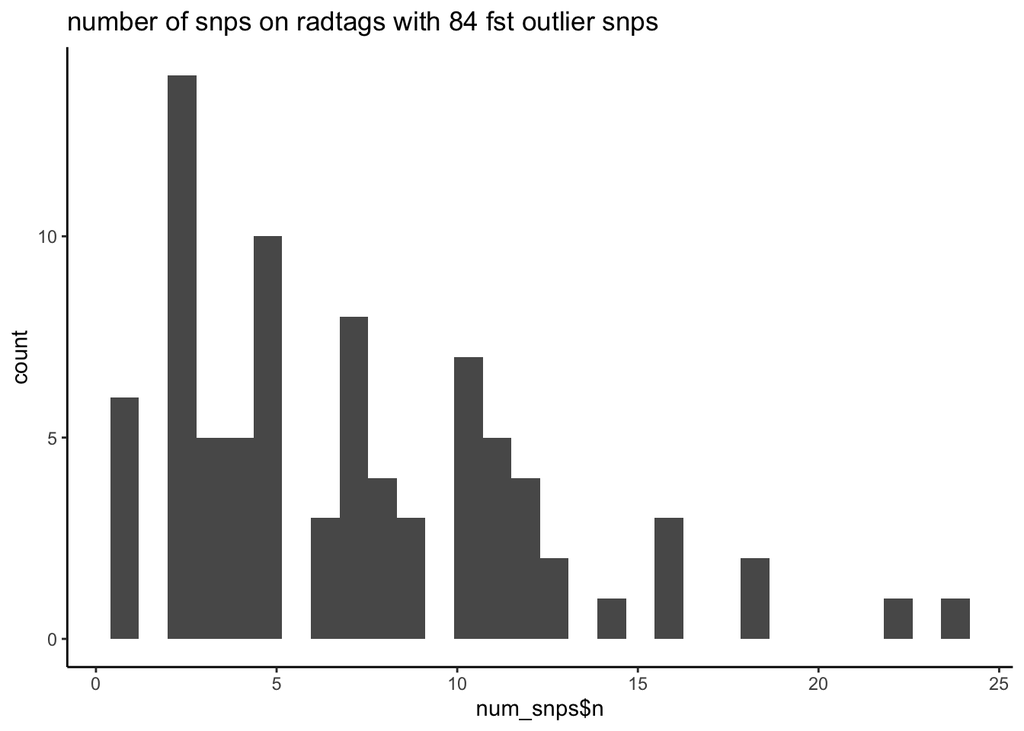

```r
snps_within_fst_tags <- read_tsv("input_data/vaux_data/snps_within_fst_radtags.txt")
num_snps <- snps_within_fst_tags %>%
  group_by(catalog_id)%>%
  tally()
ggplot(data = num_snps)+geom_histogram(aes(num_snps$n))+theme_classic()+ggtitle("number of snps on radtags with 84 fst outlier snps")
```

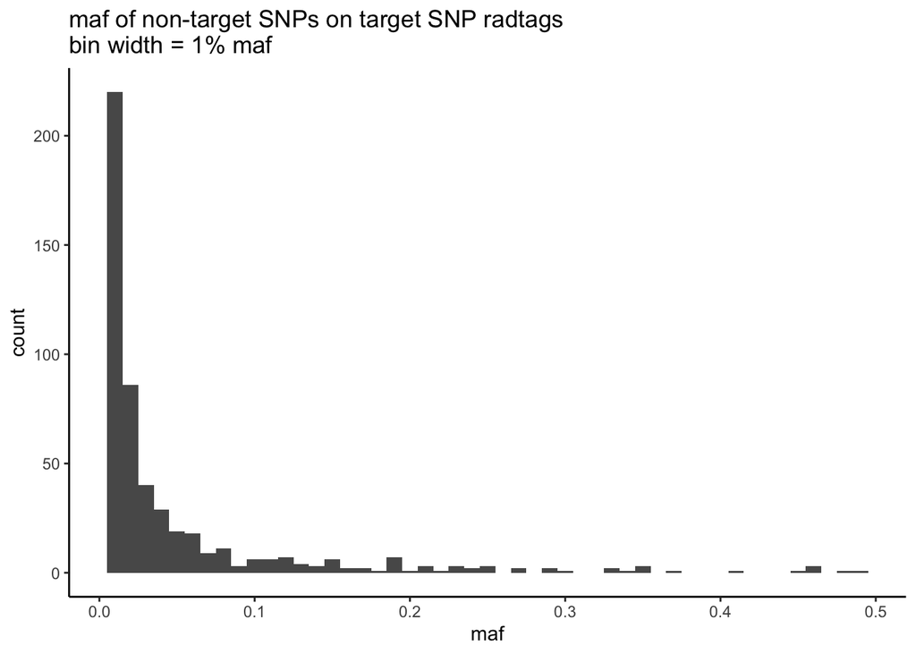

```r
snps_within_fst_tags$snpID <- paste(snps_within_fst_tags$chr, snps_within_fst_tags$pos, sep = "_")
snps_within_fst_tags$target_snp <- snps_within_fst_tags$snpID %in% n_s_84_info$snpID

ggplot(data = filter(snps_within_fst_tags, !(snpID %in% n_s_84_info$snpID)))+geom_histogram(aes(x = maf), binwidth = 0.01)+theme_classic()+ggtitle("maf of non-target SNPs on target SNP radtags\nbin width = 1% maf")
```

Here we need to make a tough decision. The more SNPs we include in the final fasta file, the more likely we will be unable to properly design primers, however, if we are masking common SNPs then this will lead to allele dropout in the pipeline down the road. i.e. too many SNPs included in the fasta file -> marker loss due to no good primers that can capture the target variants. too few SNPs -> we will get a primer that amplifies the target amplicon well, but we’ll lose a lot of reads due to null alleles (variants covering primer or probe sequence). We should make the decision on the basis of MAF. rare variants are unlikely to be important to capture in the panel because our sample sizes won’t be big enough to make good use of them and they are unlikely to lead to a ton of lost data because only a small minority of sample will contain the rare SNP. Let’s go for a 1% MAF cutoff here. If we go for 5% we’ll lose the vast majority of this information.

Strategy for about 50bp on either side of the target SNP include all variants above a cutoff MAF as target SNPs, mask all other variants (but include them so primer design can go forward with maximum information)

## FST Check

Let’s check that these 84 are strong N-S FST outliers.

Fortunately there’s already a stacks-calculated FST estimate for all stacks loci included the final populations run. We’ll check if these 84 are strong outliers in the total distribution.

```r
fst_stacks <- read_tsv("input_data/vaux_data/populations.fst_NP-SP.tsv")

fst_stacks$outlier_84 <- fst_stacks$`# Locus ID` %in% n_s_84_info$catalog_number
ggplot(data = fst_stacks)+geom_density(aes(x = `Corrected AMOVA Fst`, fill = outlier_84), alpha = 0.5)+theme_classic()

fst_stacks$outlier_84 <- fst_stacks$`# Locus ID` %in% n_s_84_info$catalog_number
ggplot(data = fst_stacks)+geom_density(aes(x = `Corrected AMOVA Fst`, fill = outlier_84), alpha = 0.5)+theme_classic()+xlim(0, 0.2)
```

[output not shown]